# Title

## 0.11 Visualize results

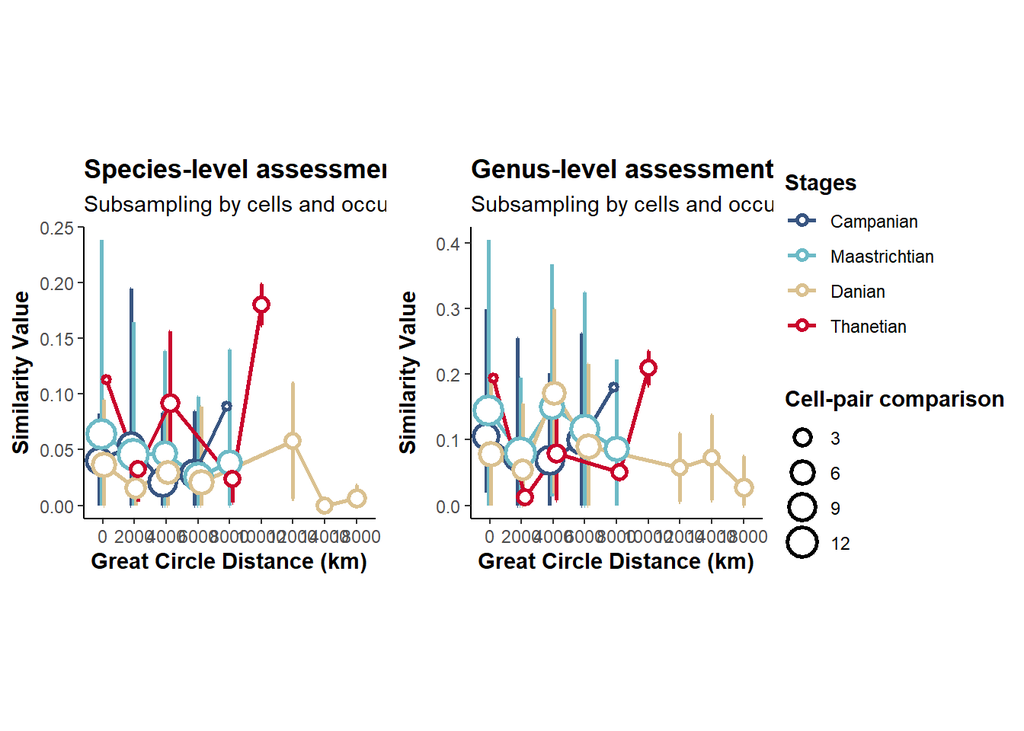

```r
# Function.
adjust_matrix <- function(x,y) {
  x |>
  rename("x.cell" = "x","y.cell" = "y") |>
  left_join(y,by = c("x.cell","y.cell"))
  }

cmp_species_input <- adjust_matrix(x = cmp_matrix,y = mean_jaccard(x = cmp_jaccard_species))
mas_species_input <- adjust_matrix(x = mas_matrix,y = mean_jaccard(x = mas_jaccard_species))
dan_species_input <- adjust_matrix(x = dan_matrix,y = mean_jaccard(x = dan_jaccard_species))
tha_species_input <- adjust_matrix(x = tha_matrix,y = mean_jaccard(x = tha_jaccard_species))

cmp_genera_input <- adjust_matrix(x = cmp_matrix,y = mean_jaccard(x = cmp_jaccard_genera))
mas_genera_input <- adjust_matrix(x = mas_matrix,y = mean_jaccard(x = mas_jaccard_genera))
dan_genera_input <- adjust_matrix(x = dan_matrix,y = mean_jaccard(x = dan_jaccard_genera))
tha_genera_input <- adjust_matrix(x = tha_matrix,y = mean_jaccard(x = tha_jaccard_genera))

# Function.
add_cutdist<- function(df, new_col = "gcd") {
  df$cutdist <- cut(df[[new_col]],
                    breaks = c(0, 2000, 4000, 6000, 8000, 10000, 12000,
                               14000, 16000, 18000, 20000),
                    labels = c("0", "2000", "4000", "6000", "8000",
                               "10000", "12000", "14000", "16000", "18000"),
                    include.lowest = TRUE)
  return(df)
} # Bin by distance between cells (GCD in km's)

cmp_species_binned <- add_cutdist(df = cmp_species_input,new_col = "gcd")
mas_species_binned <- add_cutdist(df = mas_species_input,new_col = "gcd")
dan_species_binned <- add_cutdist(df = dan_species_input,new_col = "gcd")
tha_species_binned <- add_cutdist(df = tha_species_input,new_col = "gcd")

cmp_genera_binned <- add_cutdist(df = cmp_genera_input,new_col = "gcd")
mas_genera_binned <- add_cutdist(df = mas_genera_input,new_col = "gcd")
dan_genera_binned <- add_cutdist(df = dan_genera_input,new_col = "gcd")
tha_genera_binned <- add_cutdist(df = tha_genera_input,new_col = "gcd")

# Function (average and standard deviation).
summary_statistics <- function(x) {
  x |>
  group_by(cutdist) |>
  summarise(
    # Jaccard.
    avg =  mean(avg_jaccard, na.rm = TRUE),
    sdev = sd(avg_jaccard, na.rm = TRUE),
    n = n(),
    se = sdev/sqrt(n),
    # Quantiles.
    first =  quantile(avg_jaccard,probs=0.05, na.rm = TRUE),
    second = quantile(avg_jaccard,probs=0.95, na.rm = TRUE)
  ) |>
  mutate(cutdist = cutdist,
         cutdist = factor(cutdist,levels = c("0","2000","4000","6000","8000","10000","12000","14000","16000","18000","20000"))) |>
  mutate(ci = se * qt(.95, n - 1), ci = as.numeric(ci)) |>
  as.data.frame() |> suppressWarnings()
  }

# Species-level analysis.
p1 <-
  bind_rows(
  summary_statistics(x = cmp_species_binned) |> mutate(label = "Campanian"),
  summary_statistics(x = mas_species_binned) |> mutate(label = "Maastrichtian"),
  summary_statistics(x = dan_species_binned) |> mutate(label = "Danian"),
  summary_statistics(x = tha_species_binned) |> mutate(label = "Thanetian")
) |>
  mutate(label = factor(label, levels = c("Campanian","Maastrichtian","Danian","Thanetian"))) |>
# Plot.
  ggplot(aes(x = cutdist, y = avg, group = label, colour = label, fill = label)) +
  geom_errorbar(aes(ymin = second, ymax = first), width = 0.05, linewidth = 1, position = position_dodge(width = 0.3)) +
  geom_line(linewidth = 1, position = position_dodge(width = 0.3)) +
  # scale_size_continuous(breaks = c(5, 10, 15, 20, 25, 30)) +
  scale_fill_manual(values = c("#385581FF","#6DBAC6FF","#DAC190FF","#C9052CFF")) +
  scale_colour_manual(values = c("#385581FF","#6DBAC6FF","#DAC190FF","#C9052CFF")) +
  geom_point(aes(size = n),shape = 21,fill = "white",stroke = 1.5,position = position_dodge(width = 0.3)) +
  labs(x = "Great Circle Distance (km)",
       y = "Similarity Value",
       title = "Species-level assessment",
       subtitle = "Subsampling by cells and occurrences", colour = "Stages", size = "Cell-pair comparison") +
  theme_classic() +
  theme(plot.title = element_text(face = "bold"),
        axis.title = element_text(face = "bold"),
        legend.title = element_text(face = "bold"),
        aspect.ratio = 1)

# Genus-level analysis.
p2 <-
  bind_rows(
  summary_statistics(x = cmp_genera_binned) |> mutate(label = "Campanian"),
  summary_statistics(x = mas_genera_binned) |> mutate(label = "Maastrichtian"),
  summary_statistics(x = dan_genera_binned) |> mutate(label = "Danian"),
  summary_statistics(x = tha_genera_binned) |> mutate(label = "Thanetian")
) |>
  mutate(label = factor(label, levels = c("Campanian","Maastrichtian","Danian","Thanetian"))) |>
# Plot.
  ggplot(aes(x = cutdist, y = avg, group = label, colour = label, fill = label)) +
  geom_errorbar(aes(ymin = second, ymax = first), width = 0.05, linewidth = 1, position = position_dodge(width = 0.3)) +
  geom_line(linewidth = 1, position = position_dodge(width = 0.3)) +
  scale_fill_manual(values = c("#385581FF","#6DBAC6FF","#DAC190FF","#C9052CFF")) +
  scale_colour_manual(values = c("#385581FF","#6DBAC6FF","#DAC190FF","#C9052CFF")) +
  geom_point(aes(size = n),shape = 21,fill = "white",stroke = 1.5,position = position_dodge(width = 0.3)) +
  labs(x = "Great Circle Distance (km)",
       y = "Similarity Value",
       title = "Genus-level assessment",
       subtitle = "Subsampling by cells and occurrences", colour = "Stages", size = "Cell-pair comparison") +
  theme_classic() +
  theme(plot.title = element_text(face = "bold"),
        axis.title = element_text(face = "bold"),
        legend.title = element_text(face = "bold"),
        aspect.ratio = 1)

ggarrange(p1,p2,ncol = 2,align = "hv",common.legend = T,legend = "right")
```

## 0.12 Co-occurrence network analysis

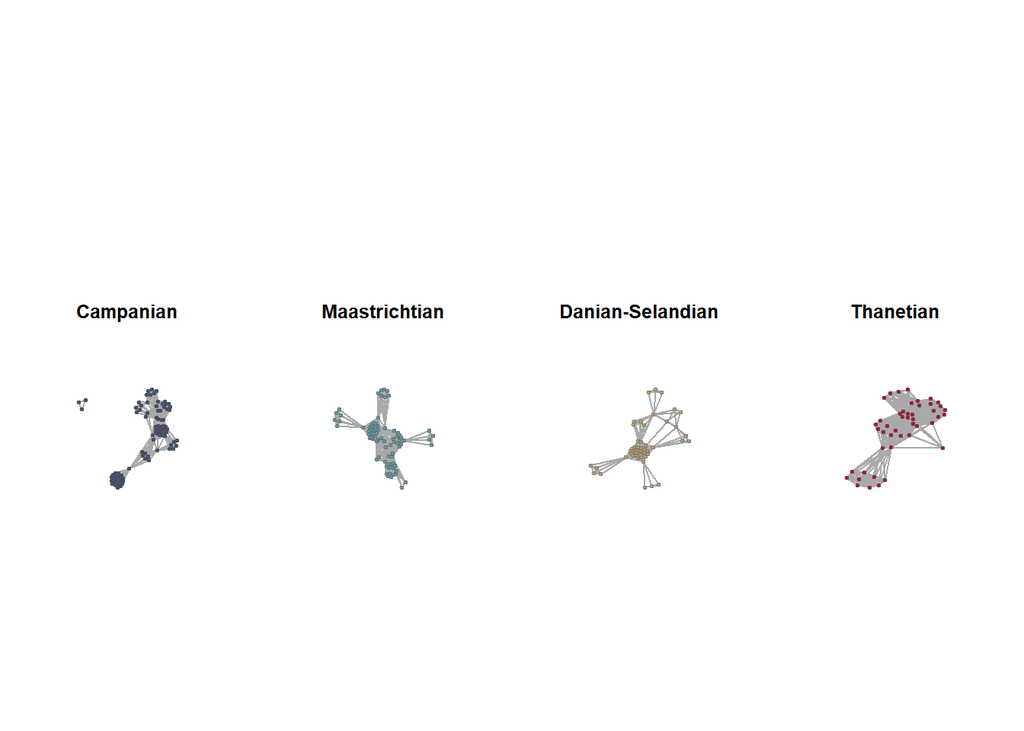

```r
# Function used to obtain species co-occurrence by stage.
co_occurrence_matrix <- function(data,age) {
  data <- data |> filter(Age.3 == age)
  data |>
  distinct(cell,Species) |>
  mutate(presence = 1) |>
  pivot_wider(names_from = Species, values_from = presence, values_fill = 0) |>
  column_to_rownames("cell") |>
  as.matrix() |>
  t() |>
  (\(x) x %*% t(x))() |>
  (\(m) { diag(m) <- 0; m })()

  }

# Plotting function.
network_function <- function(occurrence_matrix,main,vertex.color){
   gfam <- graph_from_adjacency_matrix(occurrence_matrix, mode = "undirected", weighted = TRUE)
   par(mai=c(0,0,1,0))
   plot(
     gfam,
     layout = layout_with_fr,
     vertex.label.family = "sans",
     vertex.size = 8,
     vertex.shape = "circle",
     vertex.color= vertex.color,
     vertex.frame.color = adjustcolor("#544948", alpha.f = .5),
     vertex.label = NA,
     main = main,
     vertex.label.cex = 1)
   }

# Co-occurrence_matrix
cmp_co_occur <- co_occurrence_matrix(data = clean_spatial_data,age = "Campanian")
mas_co_occur <- co_occurrence_matrix(data = clean_spatial_data,age = "Maastrichtian")
dan_co_occur <- co_occurrence_matrix(data = clean_spatial_data,age = "DanSelCombined")
tha_co_occur <- co_occurrence_matrix(data = clean_spatial_data,age = "Thanetian")

# Plot the results.
layout(matrix(c(1:4),nrow = 1,ncol = 4),respect = T)

network_function(occurrence_matrix = cmp_co_occur,main = "Campanian",vertex.color = "#385581FF")
network_function(occurrence_matrix = mas_co_occur,main = "Maastrichtian",vertex.color = "#6DBAC6FF")
network_function(occurrence_matrix = dan_co_occur,main = "Danian-Selandian",vertex.color = "#DAC190FF")
network_function(occurrence_matrix = tha_co_occur,main = "Thanetian",vertex.color = "#C9052CFF")
```

```r
# Metrics
# modularity(cluster_louvain())
# mean(degree(g))
# edge_density(g)
```

## 0.13 Basemap

Here I used chronosphere to get coastlines and elevation, although you are probably less interested in the later.

Coastline Dataset: Indices can be found by viewing the dataset https://chronosphere.info/data/paleomap/paleocoastlines/

Indices for paleomap and paleoatlas are not the same

Topography Dataset (indices at bottom of pdf) https://www.researchgate.net/profile/Christopher-Scotese/publication/301893396_PALEOMAP_PaleoAtlas_for_GPlates_and_the_PaleoData_Plotter_Program/links/5afa0551458515c00b6baebd/PALEOMAP-PaleoAtlas-for-GPlates-and-the-PaleoData-Plotter-Program.pdf

Either way , I set up your code to plot using ggplot to plot coastlines and overlay the icosa map at a minimum. Running topography base layer can be time consuming and you might want to play around with color scheme so I set it up and commented some stuff out so it won’t take so long to run.

```r
library("chronosphere")
library("via") #dependency
library("ncdf4")
library("viridis")
library("divvy")
```

```r
# Fetch the datasets, this can take a few seconds
basemap <- fetch(src = "paleomap", ser = "paleoatlas")
```

[output not shown]

[output not shown]

```
------------------------------------------------------------
Item no. 2313, src:paleomap, ser: paleoatlas, ver: v3, res: 0.1.
------------------------------------------------------------
```

[output not shown]

[output not shown]

```
MD5 checksum passed.
```

```
If you use the data in publications, please cite its
reference(s), as well as that of the 'chronosphere' project.
```

```
Scotese, C. R. (2016). PALEOMAP PaleoAtlas for GPlates and the PaleoData Plotter Program. http://www.earthbyte.org/paleomap‐ paleoatlas‐for‐gplates
```

```
Scotese, C. (2016). PALEOMAP PaleoAtlas for GPlates (Version v3). Zenodo. https://doi.org/10.5281/zenodo.10251792
```

```r
coastlines <- fetch(src = "paleomap", ser = "paleocoastlines")
```

[output not shown]

[output not shown]

```
------------------------------------------------------------
Item no. 27, src:paleomap, ser: paleocoastlines, ver: 7, res: NA.
------------------------------------------------------------
```

[output not shown]

[output not shown]

```
MD5 checksum passed.
```

```
If you use the data in publications, please cite its
reference(s), as well as that of the 'chronosphere' project.
```

```
Kocsis, Á. T., & Scotese, C. R. (2021). Mapping paleocoastlines and continental flooding during the Phanerozoic. Earth-Science Reviews, 213, 103463. https://doi.org/10.1016/j.earscirev.2020.103463
```

```
Kocsis, A. T., & Scotese, C. R. (2023). PaleoMAP PaleoCoastlines data (7.2) [Data set]. Zenodo. https://doi.org/10.5281/zenodo.7828387
```

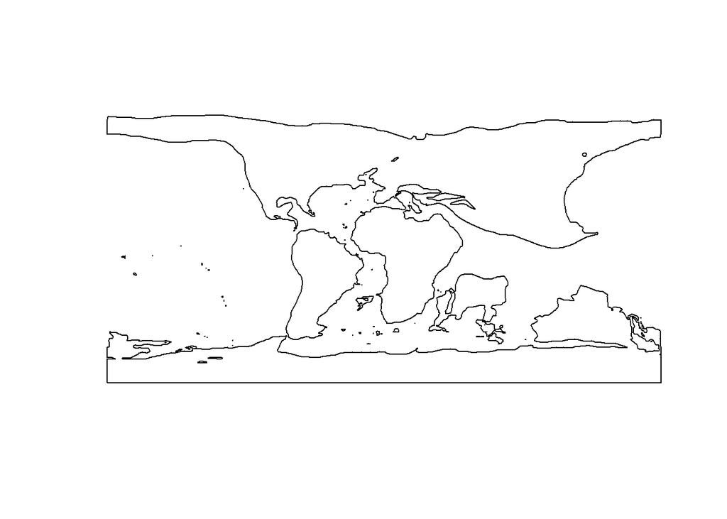

```r
#demonstrate for Campanian (77.6 Ma)

topo_camp <- basemap[[19]] #80.3 Ma       class: spatraster
coast_camp <- coastlines[[15]] # 80 Ma    class: sfc_POLYGON"

plot(coast_camp)
```

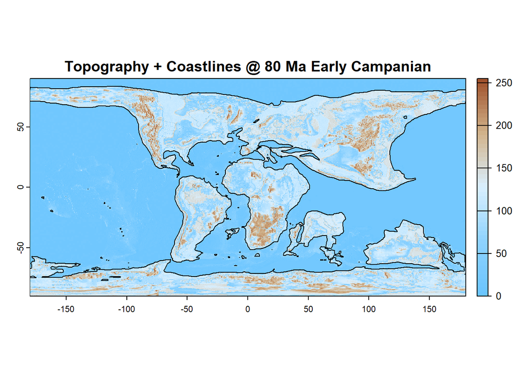

```r
#plot using base R
elev_palette<- colorRampPalette(c("#6ac5fe", "#8fd3fe", "#daf0ff", "tan","sienna" ))

plot(topo_camp,
     col = elev_palette(50),
     main = paste("Topography + Coastlines @ 80 Ma Early Campanian"))

# Overlay coastlines
plot(coast_camp,
     border = "black",
     lwd = 1.2,
     add = TRUE)
```

```r
#convert all to shapefiles and reproject to mollwiede

coast_sf <- sf::st_as_sf(coast_camp)
coast_sf <-sf::st_transform(coast_sf, crs = "ESRI:54009")

hexa_sf <- hexa@sf
hexa_sf <- sf::st_transform(hexa_sf, crs = "ESRI:54009")#mollwiede

#you can convert to mollwiede but it will take an exorbitantly long time to run, I'm not sure why it makes a difference. It also doesn't look great so I have commented it out.


#crs(topo_camp) <- "EPSG:4326"
#topo_moll <- terra::project(topo_camp, "ESRI:54009")


topo_df <- as.data.frame(topo_camp, xy = TRUE) #change to topo_moll if convert to mollweide

topo_df <- topo_df %>%
  rename(elevation = `Map19a LtK Early Campanian_080_1`)
```

```r
# add occs to hexa_sf
hexa_sf <- hexa_sf %>%
  left_join(
    campanian_cells %>% select(cell, occs),
    by = c("faces" = "cell")
  )

#assign all na to zero for plotting purposes
hexa_sf$occs[is.na(hexa_sf$occs)] <- 0
```

You might want to play with the ordering of the layers or transparency or gradient fill.

Plot coastlines with occurences in hexacells overlayed

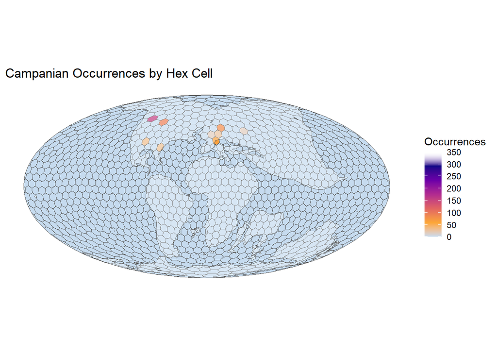

```r
vir_colors <- rev(viridis(6, option = "C"))[2:7]

pal_colors <- c("#c6dbef", vir_colors)# this makes any hexacell with value occs = 0 a blue color.

ggplot() +

  geom_sf(data = hexa_sf, aes(fill = occs), size = 0.1) +
  geom_sf(data = coast_sf, fill = scales::alpha("white", 0.3)) +
  scale_fill_gradientn(
    colors = pal_colors,
    breaks = seq(0, 350, 50),
    limits = c(0, 350),
    name = "Occurrences"
  ) +
  labs(title = "Campanian Occurrences by Hex Cell") +
  theme_minimal()
```

Some of this is commented out because the colorscheme is making the lower layer not visible. I didn’t put a lot of effort into it because I’m not sure ultimatley if you want the topo_map or not.

```r
# beware this can take a while to run

#library(ggnewscale)


#ggplot() +
 # geom_raster(data = topo_df, aes(x = x, y = y, fill = elevation)) +

  #scale_fill_viridis_c(name = "Elevation") +

  #new_scale_fill() +  # start new fill scale

  #geom_sf(data = hexa_sf, aes(fill = occs), size = 0.1) +

#  scale_fill_gradientn(
 #   colors = pal_colors,
  #  breaks = seq(0, 350, 50),
   # limits = c(0, 350),
    #name = "Occurrences",
    #na.value = scales::alpha("white", 0)
  #) +

#  labs(title = "Campanian Occurrences by Hex Cell") +
 # theme_minimal()
```

# 1 Divvy Subsampling

This is basic set up for divvy. I did not split any of the data into time bins or introduce icosa grid cells yet. Right now it is taking absolute paleolat/long and performing the samping routing on a equal area rectangulargrid. Once verified successful I will build icosa into the framework.

```r
rWorld <- rast()
prj <- 'EPSG:8857' #you just need to assign a rectangular grid here

rPrj <- terra::project(rWorld, prj, res = 200000) # 200,000m is approximately 2 degrees, change as you see suitable for hexagrid size

# coordinate column names for the current and target coordinate reference system

xyCell   <- c('paleolng','paleolat')

llOccs <- vect(clean_spatial_data, geom = c("paleolong", "paleolat"), crs = "epsg:4326") # you need an equal area projection here


prjOccs <- terra::project(llOccs, prj)
cellIds <- cells(rPrj, prjOccs)[,'cell']
clean_spatial_data[, xyCell] <- xyFromCell(rPrj, cellIds)
```

Perform a summary check on data before spatial standardization to make sure it didn’t drop anything and also can compare to your other metrics like great circle distance above.

```r
#

un_samp_summary <- sdSumry(clean_spatial_data,
                        taxVar =    'Species',
                        xy = xyCell,

                        crs = prj)

un_samp_summary
```

```
     nOcc nLoc centroidX centroidY latRange greatCircDist meanPairDist
[1,]  379   45  -1161737   3890551  110.924      19645.86      4932.01
     minSpanTree     SCOR nTax
[1,]    39646.17 8.731459  213
```

```r
#divvy_spatial_data <- uniqify(clean_spatial_data, taxVar = 'Species', xy = xyCell)
```

Subsampling using rectangular grid

```r
#need to use divvy_spatial_data

set.seed(1)
circLocs <- cookies(dat = clean_spatial_data,
                    xy = xyCell,
                    iter = 500,
                    nSite = 12,
                    r = 1500, # radial distance in km
                    weight = TRUE, # probabilistically aggregate subsampling sites
                    crs = prj, # Equal Earth projection
                    output = 'full')
length(circLocs)
```

```
[1] 500
```

```r
#calcualte summary for first iteration
samp1 <- sdSumry(dat = circLocs[[1]],
                 taxVar =    'Species',
                 xy = xyCell,
                 omitDom = TRUE,
                 crs = prj)
samp1
```

```
     nOcc nLoc centroidX centroidY latRange greatCircDist meanPairDist
[1,]  139   12   1156041   4972773 12.51064          1400     664.1245
     minSpanTree     SCOR nTax
[1,]    3262.742 12.60343   94
```

Visualize (not fully working yet)

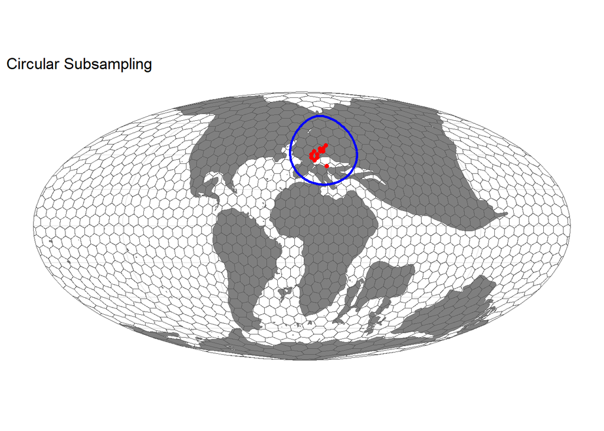

```r
points_sf <- sf::st_as_sf(clean_spatial_data, coords = c("paleolong", "paleolat"), crs = 4326)

#convert points in dataset to mollweide
pointsMoll <- sf::st_transform(points_sf, crs = "ESRI:54030")

smplPts <- st_as_sf(circLocs[[1]], coords = xyCell, crs = prj)
cntr <- smplPts[1,]

# distances inferred to be meters based on lat-long coord system
r <- 1500
buf <- st_buffer(cntr, dist = r*1500)

circ_sub_plot <- ggplot() +


geom_sf(data = coast_sf, fill = "gray50", color = "gray40", size = 0.3) +
geom_sf(data = hexa_sf, size = 0.3, fill = NA) +  # no fill for hexes

  geom_sf(data = pointsMoll, size = 2, alpha = 0.5)+
  geom_sf(data = buf, fill = NA, linewidth = 1, color = 'blue') +  # buffer zone circle
  geom_sf(data = smplPts, shape = 16, color = 'red') +  # sampled points
  theme_minimal() +
  labs(title = "Circular Subsampling")

  circ_sub_plot
```

You can apply a custom function to the divvy output which is a nested list using purrr::map(). Pass each element of circlLocs to BC

```r
connectedness <- purrr::map(circLocs, ~BC(.x$Species, .x$cell))

connectedness[[1]]
```

```
[1] 0.8446809
```

Calculate IQR of connectedness for dataset

```r
#connectedness is a list of values, not nested. convert to a vector
connectedness_vec <- unlist(connectedness)

iqr_values <- tibble(connectedness = connectedness_vec) %>%
  summarise(
    median = median(connectedness, na.rm = TRUE),
    q1 = quantile(connectedness, 0.25, type = 5, na.rm = TRUE),
    q3 = quantile(connectedness, 0.75, type = 5, na.rm = TRUE),
    iqr = IQR(connectedness, na.rm = TRUE)
  )

iqr_values
```

```
# A tibble: 1 × 4
  median    q1    q3   iqr
   <dbl> <dbl> <dbl> <dbl>
1  0.787 0.689 0.928 0.239
```

Implement icosa, you can compare output between using icosa and rectangular equal area projections using divvy::summary()

```r
#find the centers of the hexagrid cells
hexa_centers <- centers(hexa, output = "polar")


# Convert to data.frame for joining
hexa_centers_df <- as.data.frame(hexa_centers)
colnames(hexa_centers_df) <- c("hexa_lon", "hexa_lat")
hexa_centers_df$cell <- seq_len(nrow(hexa_centers_df))

hexa_centers_df$cell <- paste0("F", hexa_centers_df$cell)

head(hexa_centers_df)
```

```
   hexa_lon hexa_lat cell
F1        0 90.00000   F1
F2     -162 84.23319   F2
F3      -90 84.23319   F3
F4      -18 84.23319   F4
F5       54 84.23319   F5
F6      126 84.23319   F6
```

```r
clean_spatial_data <- clean_spatial_data %>% # this is a dataframe, to plot need to convert to sf obejct

  left_join(hexa_centers_df, by = "cell")

names(clean_spatial_data)
```

```
 [1] "cell"
 [2] "cell_id"
 [3] "Source"
 [4] "Image.Label"
 [5] "File.Name"
 [6] "Dental.Unit"
 [7] "Sp#"
 [8] "View"
 [9] "Standardized.Position"
[10] "Relative.Position"
[11] "Clade"
[12] "Superorder"
[13] "Order"
[14] "Family"
[15] "Genus"
```

[output cut: 38 more lines]